# Comparing the Performance of Different Forecasting Models to Predict Major Currency Exchange Rates

###### by Muhammad Bagir, Sithipath Yooprong, Zain Abdelrazeq

**Introduction:**

Exchange rates float freely against one another, which can be problematic because they are in constant fluctuation and can impact a country's economic performance, including merchandise trade, economic growth, capital flows, inflation, and interest rates.

In this course project, we theoretically analyzed various machine learning models to study the day-to-day movement of exchange rates and made predictions based on historical data. The study's insight could be beneficial to every stakeholder in the foreign exchange market.

For the public sector, the prediction of the major exchange rates enables policymakers to mitigate the impact of foreign exchange risk, which include the losses that an international financial transaction may incur due to currency fluctuations. This mitigation helps ensure economic stability and contain excessive fluctuations.

For the private sector, this risk can apply to many scenarios, such as an international manufacturing company in China incurring a cost of ¥ but revenue in USD. The exchange rate projection helps the company mitigate the risk by optimally managing the company's cash flows or purchasing currency warrants.

We utilized historical data from Kaggle, which was generated from the Federal Reserve's Download Data Program. We then created machine learning models using different techniques to forecast the exchange rates and provided theoretical results based on various benchmarks, such as MAE, MSE, RMSE, and MAPE.

**2 Background**

#### 2.1 Foreign Exchange

Foreign exchange, also known as forex or FX, refers to the global market where currencies are traded. It is the world's largest and most liquid financial market, with a daily trading volume of over USD 6.6 trillion in 2019. In the foreign exchange market, participants buy, sell, and exchange currencies. This market allows for converting one currency into another, enabling international trade and investment. The value of currencies constantly fluctuates due to various factors, such as interest rates, economic indicators, and political events.

International banks are the main participants in this market. Except for weekends, the trading between a wide range of multiple types of buyers and sellers occurs around the clock, with financial centers around the world functioning as anchors[8]. Since currencies are always traded in pairs, the foreign exchange market does not set a currency’s absolute value, but rather determines its relative value by setting the market price of one currency if paid for with another.

#### 2.2 Forex Time-Series Dataset

In forex, a time series data set is a collection of historical exchange rate data for a particular currency pair. The time series data set can be used to analyze the trends and patterns in the exchange rates and make predictions about future movements in the market. Traders and investors often use this type of analysis to make decisions about when to buy or sell currencies. Time series analysis can also be used to identify patterns and trends in the data, which can be useful for identifying potential trading opportunities.

**3 Method**

To predict the exchange rates of currencies against the USD, we used traditional machine learning algorithms, including Regression Tree (RT), Random Forest (RF), and Support Vector Regression (SVR), as well as deep learning-based algorithms, including Long Short-Term Memory (LSTM) and Bi-directional Long Short-Term Memory (Bi-LSTM).

### 3.1 Traditional Machine Learning Algorithms

Regression tree is a common practical approach for supervised learning and is a tree-structured classifier; it includes a root node, an interior node, and a leaf node. The root node represents the whole sample, the interior node represents the characteristic of the data set, and the root node provides the outcome. The decision tree is run by answering true/false questions until the leaf node is reached, and the prediction is calculated by finding the average value of a dependent variable in a specific leaf node. Using this approach, the tree can predict a value for a data point through several iterations. Using an ensemble of decision trees can help overcome overfitting problems.

Random Forest follows the idea of randomization and is an ensemble algorithm that builds independent and non-identical decision trees. RF is a combination of tree predictors, where each decision tree uses a random vector as a parameter that randomly chooses the attributes of samples. The sample subset is then chosen as the training dataset. The strength and correlation of the forest's individual trees affect the generalization error of a forest of trees. A significant advantage of RF is its versatility. Overfitting problems are avoided by generating random subsets of attributes and constructing trees using these subsets.

Support Vector Regression is also used in this study for comparative purposes. SVR is a supervised machine learning algorithm that has a strong generalization capability and a high prediction accuracy. The computation does not depend on dimensionality, which works well for large datasets. The algorithm defines a boundary based on the support vector points, and it predicts sample points within that boundary.

### 3.2 Deep Learning-based Algorithms

In our study, we also applied deep learning approaches to predict the exchange rates of currencies. The Long Short-Term Memory (LSTM) is a recurrent neural network algorithm in the field of deep learning that performs well when analyzing time-series data. LSTM overcomes the problem of having no memory associated with it by creating a short-term and a long-term memory component. This being said, LSTM works only with previous data patterns. It captures the long-term dependency and determines the optimal lag order in the time-series analysis. Using memory cells, LSTM overcomes the problem of vanishing gradient. The LSTM network includes the delays and the sizes of the hidden layers obtained from the time-series training data.

LSTM cannot handle the data when the inputs and outputs are of different sizes, so Bi-directional LSTM (Bi-LSTM) was used, which overcomes this problem by considering previous and future data patterns, leading to effective learning of long-term dependencies in the time-series data. The bidirectional nature of input patterns makes Bi-LSTM efficient in analyzing time-series data; it considers previous and future data during training. This helps Bi-LSTM learn the present status of the data from past and future data through its forward and backward layer, where layers have no hidden-to-hidden connections, making it easier to understand information from backward and forward layers in each Bi-LSTM unit. Bi-LSTM captures both local features as well as extracts global features in the time-series data.

### 4 Experimental Analysis

#### 4.1 Dataset for the Experiments

The dataset for the experiment is Foreign Exchange Rates 2000-2019 from Kaggle, which contains 5216 daily observations of 21 major currencies used all around the world from the year 2000 to 2019.

#### 4.2 Data Preprocessing

Four steps were needed to pre-process the data, including:

1. Selecting the currencies of interest: there are 22 currencies available in the dataset. For the purposes of this study, we chose the top 10 most traded currencies based on the forex market.
2. Handling missing values: among the 5216 daily observations, there are 198 daily observations missing from the dataset for every currency. We decided to replace them with the average value.
3. Min-Max scaling of the data: since every currency has a different range of value, we min-max scaled every currency. The min-max scale was chosen instead of the Z-score normalization because the daily observations of currencies are usually close to the day before. Hence, Z-score normalization was not needed to handle extreme values.
4. Defining the training and test sets: the dataset was split into 80:20 for training and test sets. Since the data is time series, the first 4174 observations were used in the training set and the rest were part of the test set. Also, when the grid-search was done for hyperparameter tuning, the data was split into a training set, validation set, and test set in the proportion of 80:10:10.

#### 4.3 Performance Measures for the Models

To measure the performance of different machine learning models, we used root mean squared error (RMSE), mean absolute error (MAE), and mean absolute percentage error (MAPE). Even though the three performance measures were considered in the study, the RMSE is the most desirable for foreign exchange prediction since it puts more weight on larger errors (Islam Hossain, 2020). The formula for the RMSE is provided below, where \( N \) is the number of data points, \( y_i \) is the actual observation, and \( \hat{y}_i \) is the estimated value:

$$ \text{RMSE} = \sqrt{\frac{1}{N} \sum_{i=1}^{N} (y_i - \hat{y}_i)^2 } $$

#### 4.4 Model Performance Analysis on 10 Currencies

After training the 5 machine learning models from the training dataset and using them to predict the foreign exchange rate for the test set, error analysis was conducted. Figure 1 shows the RMSE of different models for the 10 currencies.

From the RMSE results on the first 10 currencies, we found that the performances of LSTM (and Bi-LSTM) and RF are very close, and they are the best three performing models in currency prediction. While the RMSE significantly increased in RT and SVR, the result was comparable to our expectations and the previous paper since the dataset is not large enough for SVR to give a competitive accuracy. Therefore, hyperparameter tuning was used on the LSTM and RF models to improve the performance.

Figure 1: The RMSE of the selected on the selected 10 currencies

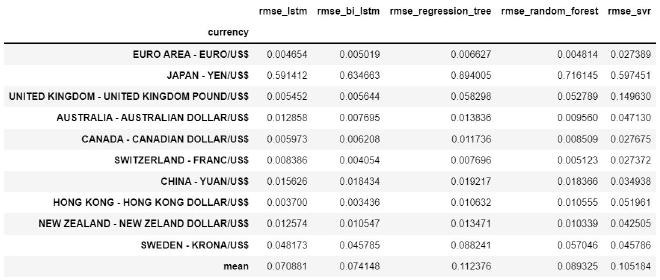

#### 4.5 Grid-search for Hyperparameter Tuning of RF and LSTM

##### 4.5.1 Random Forest

Since every currency has a different best performing model with a different set of hyperparameters, error analysis and hyperparameter tuning was done on EURO/USD. To do that, the dataset was split into a training set, validation set, and test set in the proportion 80:10:10.

The grid search was done on four hyperparameters, including:

1. **n_estimators:** The number of trees we want to build before taking the maximum voting or averages of predictions. With lower n_estimators, it can cause the tree to be overfitted. The range used was [60, 80, 100].
2. **The maximum depth of the decision trees:** Since the higher number of maximum depth can cause overfitting, the range used was [None, 1, 2, 3].
3. **min_samples_split:** The minimum sample required to split an internal node since the higher number of min_samples_split can prevent the tree from overfitting. The range used was [1, 2, 3].
4. **min_samples_leaf:** This is defined as the minimum number of samples required to be at a leaf node. A large number of min_samples_leaf can prevent the tree from overfitting. The range used was [1, 7, 8, 9].

For the possible value of each parameter, an empirical study was followed from the article "How to tune a Decision Tree?".

The table below presents the best parameters found for the RF:

| Hyperparameter | Value |
| --- | --- |
| maximum depth | None |
| minimum samples in leaf node | 1 |
| minimum samples required to split | 2 |
| number of trees | 100 |

According to the grid search, the best model was using the above hyperparameters, which are the default values of the Random Forest Model in the sklearn library. After applying these hyperparameters, using the new dataset split, the RMSE were 0.004814 for the training set, 0.005705 for the validation dataset, and 0.004937 for the test dataset.

##### 4.5.2 Hyperparameter Tuning of LSTM

Figure 2: The RMSE of LSTM model for EURO with different epochs

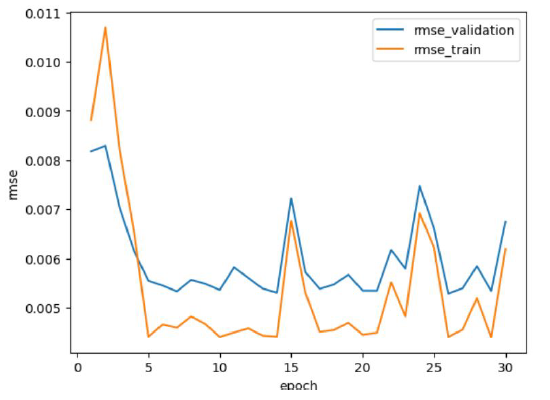

#### 4.6 Results and Additional Analysis

After hyperparameter tuning, the best-performing model was still LSTM. However, the RF model can also give slightly less accurate but good predictions with significantly less run time. This conclusion is in line with the prior study (Mohammad Zeynol Abedin), as well as the value of RMSE of the LSTM model, which is in the baseline of 0.005-0.01.

To explore predicting forex currencies further, which the prior study did not cover, we explored using multiple currencies to predict the daily observation of one currency. Moreover, we used the historical data of YEN/USD, United Kingdom POUND/USD, YUAN/USD, and EURO/USD to predict the value of EURO/USD the next day. We concluded that having multiple currencies to predict one currency marginally helps improve the accuracy of the prediction. The result is presented in Appendix 2.

#### 5 Conclusion

In conclusion, our analysis showed that machine learning models can be effective for predicting foreign exchange currencies. We trained and evaluated five different machine learning models on a dataset of historical foreign exchange data, and found that deep-learning models provided the most accurate predictions.

There are still many open problems and directions for further research in this area. For example, one open problem is dealing with the high volatility and complexity of the foreign exchange market, which can make it challenging for machine learning models to accurately capture underlying patterns and trends. Another open problem is the availability of high-quality, real-time data for training and evaluating machine learning models. In addition, there is a need to develop effective methods for incorporating additional sources of information, such as news and economic indicators, into machine learning models for foreign exchange prediction.

Overall, the use of machine learning for foreign exchange prediction holds great potential and warrants continued investigation.

#### References

1. Mohammad Zoynul Abedin (2021) Deep learning-based exchange rate prediction during the COVID-19 pandemic, [link.springer.com](https://link.springer.com/article/10.1007/s10479-021-04420-6) accessed 11/2/2022
2. M.S. Islam (2021) Foreign exchange currency rate prediction using a GRU-LSTM hybrid network, [sciencedirect.com](https://www.sciencedirect.com/science/article/pii/S2666222120300083?via3Dihub) accessed 11/4/2022
3. Mu-Yen Chen (2011) Predicting corporate financial distress based on integration of decision tree classification and logistic regression, [sciencedirect.com](https://www.sciencedirect.com/science/article/abs/pii/S0957417411003976?via3Dihub) accessed 11/7/2022
4. Salma Alhagry (2017) Emotion Recognition based on EEG using LSTM Recurrent Neural Network, [semanticscholar.org](https://pdfs.semanticscholar.org/6a4d/4bf50c412635335af1b8444d427d9c3e8c86.pdf) accessed 11/8/2022
5. Shaolong Sun (2020) A new ensemble deep learning approach for exchange rates forecasting and trading, [sciencedirect.com](https://www.sciencedirect.com/science/article/abs/pii/S1474034620301312) accessed 11/8/2022
6. CR Geisst (2009) Encyclopedia of American Business History, ISBN 1438109873
7. Anooja Debnath (2019) Global Currency Trading Surges to USD 6.6 Trillion-A-Day Market, [bloomberg.com](https://www.bloomberg.com/news/articles/2019-09-16/global-currency-trading-surges-to-6-6-trillion-a-day-market) accessed 12/5/2022
8. GW Bromiley (2012) International Standard Bible Encyclopedia, ISBN 0802837816

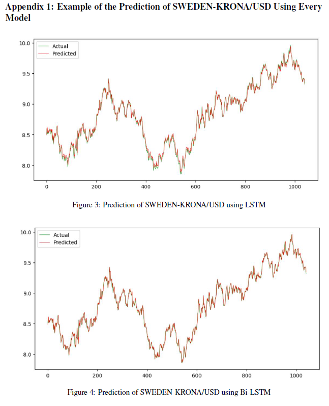

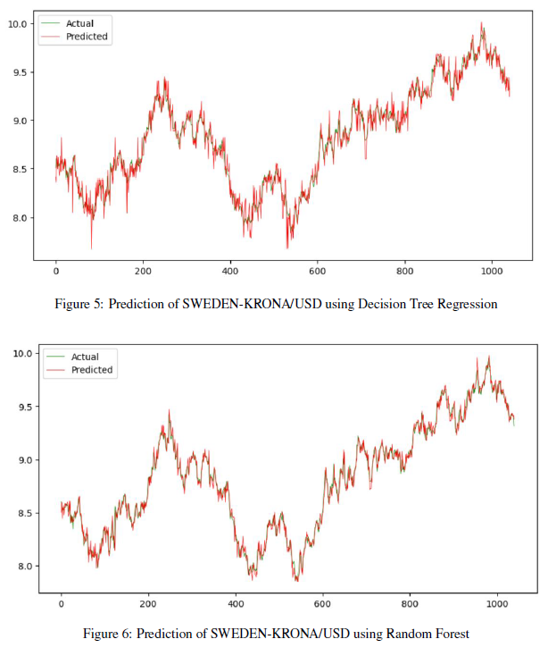

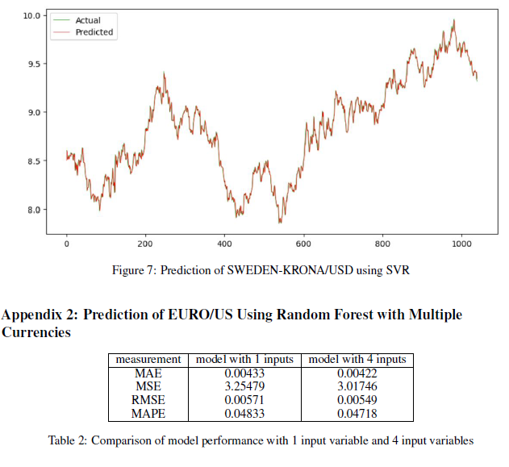